# Task2_Final

Harshrim Pardal

6/9/2021

**Loading the Dataset**

```r
library(readxl)
library(DataExplorer)
data2<-read_xlsx("D:\\RIMA\\MBA\\Christ\\SIP-Outlook\\Data\\Tree Making.xlsx",sheet=1)
head(data2)
```

```
## # A tibble: 6 x 15
##      CRIM    ZN INDUS  CHAS   NOX    RM   AGE   DIS   RAD   TAX PTRATIO     B
##     <dbl> <dbl> <dbl> <dbl> <dbl> <dbl> <dbl> <dbl> <dbl> <dbl>   <dbl> <dbl>
## 1 0.00632    18  2.31     0 0.538  6.58  65.2  4.09     1   296    15.3  397.
## 2 0.0273      0  7.07     0 0.469  6.42  78.9  4.97     2   242    17.8  397.
## 3 0.0273      0  7.07     0 0.469  7.18  61.1  4.97     2   242    17.8  393.
## 4 0.0324      0  2.18     0 0.458  7.00  45.8  6.06     3   222    18.7  395.
## 5 0.0690      0  2.18     0 0.458  7.15  54.2  6.06     3   222    18.7  397.
## 6 0.0298      0  2.18     0 0.458  6.43  58.7  6.06     3   222    18.7  394.
## # ... with 3 more variables: LSTAT <dbl>, MEDV <dbl>, CAT.MEDV <dbl>
```

```r
dim(data2)
```

```
## [1] 506  15
```

```r
sapply(names(data2),class)
```

```
##        CRIM          ZN       INDUS        CHAS         NOX          RM
## "character" "character" "character" "character" "character" "character"
##         AGE         DIS         RAD         TAX     PTRATIO           B
## "character" "character" "character" "character" "character" "character"
##       LSTAT        MEDV    CAT.MEDV
## "character" "character" "character"
```

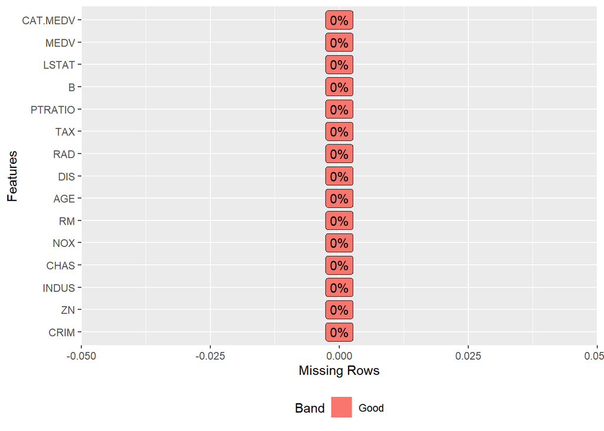

```r
plot_missing(data2)
```

**Splitting the dataset into training and testing dataset**

```r
library(caTools)
#Creating a subset of 70% data
set.seed(100)
split1<-sample.split(data2$MEDV, SplitRatio=0.7)
data1train<-subset(data2, split1==TRUE)
data1test<-subset(data2, split1==FALSE)
```

**EXPLANATION**

The training dataset is stored in data1train The testing dataset is stored in data1test

**Decision Tree -**

Decision Tree 1 - The value of CAT.MEDV is classified as 0 or 1 depending on all other variables in the dataset

```r
reg2<-lm(CAT.MEDV~ .,data=data1train)
summary(reg2)
```

```
##
## Call:
## lm(formula = CAT.MEDV ~ ., data = data1train)
##
## Residuals:
##      Min       1Q   Median       3Q      Max
## -0.53780 -0.11040 -0.01730  0.07693  0.64466
##
## Coefficients:
##               Estimate Std. Error t value             Pr(>|t|)
## (Intercept) -1.4956954  0.2726117  -5.487         0.0000000785 ***
## CRIM         0.0071068  0.0024991   2.844             0.004719 **
## ZN           0.0026960  0.0006759   3.989         0.0000808889 ***
## INDUS       -0.0108315  0.0032317  -3.352             0.000891 ***
## CHAS        -0.0130173  0.0465055  -0.280             0.779711
## NOX          0.3927951  0.1987331   1.976             0.048879 *
## RM           0.0938614  0.0242392   3.872             0.000129 ***
## AGE          0.0004426  0.0006554   0.675             0.499937
## DIS         -0.0198708  0.0104705  -1.898             0.058541 .
## RAD         -0.0049196  0.0036525  -1.347             0.178871
## TAX          0.0001479  0.0002016   0.733             0.463782
## PTRATIO      0.0042124  0.0069073   0.610             0.542355
## B           -0.0001485  0.0001474  -1.007             0.314401
## LSTAT        0.0122930  0.0029835   4.120         0.0000472174 ***
## MEDV         0.0346224  0.0023779  14.560 < 0.0000000000000002 ***
## ---
## Signif. codes:  0 '***' 0.001 '**' 0.01 '*' 0.05 '.' 0.1 ' ' 1
##
## Residual standard error: 0.2036 on 352 degrees of freedom
## Multiple R-squared:  0.7395, Adjusted R-squared:  0.7291
## F-statistic: 71.37 on 14 and 352 DF,  p-value: < 0.00000000000000022
```

```r
#reg1$fitted.values
library(rpart)
library(rpart.plot)
tree2 =rpart(CAT.MEDV ~., data=data1train)
prp(tree2, box.palette="Blues")
varImp(tree2)
```

```
##           Overall
## INDUS   0.2861961
## LSTAT   0.4357099
## MEDV    1.0000000
## PTRATIO 0.1964069
## RM      0.6507582
## CRIM    0.0000000
## ZN      0.0000000
## CHAS    0.0000000
## NOX     0.0000000
## AGE     0.0000000
## DIS     0.0000000
## RAD     0.0000000
## TAX     0.0000000
## B       0.0000000
```

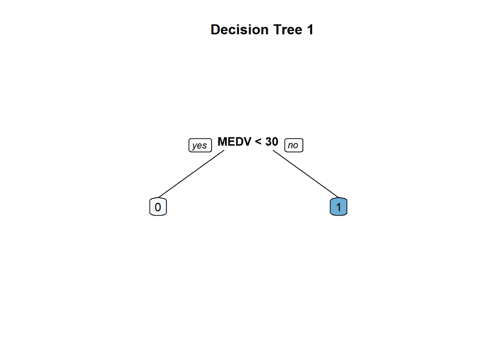

```r
title("Decision Tree 1")
```

**EXPLANATION**

The dependent Variable(DV) in this model is CAT.MEDV which is a scaled variable and can take two values - either 0 or 1 . The independent variables used are CRIM,ZN,INDUS,CHAS,NOX,RM,AGE,DIS,RAD,TAX,PTRATIO,B,LSTAT,MEDV

Using this these variables and the training dataset regression model is built p-value>0.05 —accept null hypothesis p-value<0.05—reject null hypothesis

Ho:Model is not good fit , Ha: Model good fit

From the output , we get a p-value of < 0.00000000000000022 which is <0.05 Thus, Null Hypothesis is rejected. Thus model is a good fit.

H0:Variable has no impact on CAT.MEDV Ha:Variable has impact on CAT.MEDV

From the output the Pr(>|t|) values of the Chosen IVs are:

CRIM, ZN, INDUS, NOX, RM,LSTAT,MEDV has impact on the value of CAT.MEDV

CHAS,DIS,RAD,TAX,PTRATIO,B has no impact on the value of CAT.MEDV

From the above tree and the output of varImp , we can see that when the entire data is selected , the most important attribute chosen by the model is MEDV and the decision tree is plotted with leaf nodes 0 and 1.

```r
reg1<-lm(CAT.MEDV~ CRIM+ZN+INDUS+CHAS+NOX+RM+AGE+DIS+RAD+TAX+PTRATIO+B+LSTAT ,data=data1train)
summary(reg1)
```

```
##
## Call:
## lm(formula = CAT.MEDV ~ CRIM + ZN + INDUS + CHAS + NOX + RM +
##     AGE + DIS + RAD + TAX + PTRATIO + B + LSTAT, data = data1train)
##
## Residuals:
##      Min       1Q   Median       3Q      Max
## -0.60069 -0.14613 -0.02425  0.12469  1.11673
##
## Coefficients:
##                Estimate  Std. Error t value             Pr(>|t|)
## (Intercept) -0.38078405  0.33071220  -1.151             0.250344
## CRIM         0.00308197  0.00313953   0.982             0.326937
## ZN           0.00394573  0.00084747   4.656          0.000004574 ***
## INDUS       -0.00931752  0.00408283  -2.282             0.023077 *
## CHAS         0.10461997  0.05788961   1.807             0.071577 .
## NOX         -0.27599296  0.24439952  -1.129             0.259551
## RM           0.25529604  0.02724552   9.370 < 0.0000000000000002 ***
## AGE          0.00068440  0.00082817   0.826             0.409137
## DIS         -0.06494912  0.01264299  -5.137          0.000000462 ***
## RAD          0.00487077  0.00453788   1.073             0.283843
## TAX         -0.00026333  0.00025236  -1.043             0.297449
## PTRATIO     -0.03059276  0.00819146  -3.735             0.000219 ***
## B            0.00008791  0.00018513   0.475             0.635183
## LSTAT       -0.00476152  0.00346843  -1.373             0.170681
## ---
## Signif. codes:  0 '***' 0.001 '**' 0.01 '*' 0.05 '.' 0.1 ' ' 1
##
## Residual standard error: 0.2574 on 353 degrees of freedom
## Multiple R-squared:  0.5826, Adjusted R-squared:  0.5672
## F-statistic:  37.9 on 13 and 353 DF,  p-value: < 0.00000000000000022
```

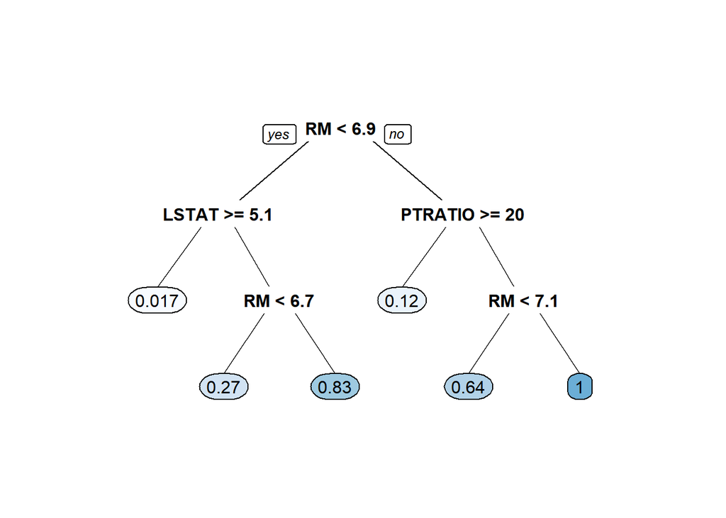

```r
#reg1$fitted.values
library(rpart)
library(rpart.plot)
tree1 =rpart(CAT.MEDV ~ CRIM+ZN+INDUS+CHAS+NOX+RM+AGE+DIS+RAD+TAX+PTRATIO+B+LSTAT, data=data2)
prp(tree1, box.palette="Blues")
```

```r
varImp(tree1)
```

```
##            Overall
## AGE     0.24838543
## CRIM    0.37305901
## DIS     0.07584105
## INDUS   0.38463491
## LSTAT   0.96685938
## NOX     0.09796037
## PTRATIO 0.66776740
## RAD     0.47101938
## RM      1.63212221
## TAX     0.67460025
## ZN      0.10259425
## CHAS    0.00000000
## B       0.00000000
```

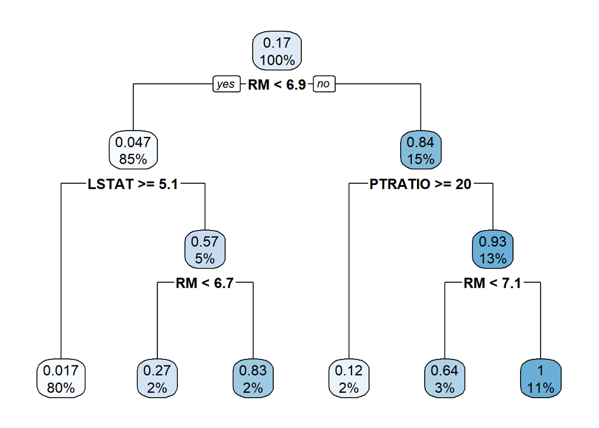

```r
bestcp1 <- tree1$cptable[which.min(tree1$cptable[,"xerror"]),"CP"]
tree1.pruned <- prune(tree1, cp = bestcp1)
rpart.plot(tree1.pruned)
```

```r
#title("Decision Tree 3")
```

```r
varImp(tree1.pruned)
```

```
##            Overall
## AGE     0.24838543
## CRIM    0.37305901
## DIS     0.07584105
## INDUS   0.38463491
## LSTAT   0.96685938
## NOX     0.09796037
## PTRATIO 0.66776740
## RAD     0.47101938
## RM      1.63212221
## TAX     0.67460025
## ZN      0.10259425
## CHAS    0.00000000
## B       0.00000000
```

```r
tree.pred = predict(tree1.pruned, newdata=data1test)
tree.pred
```

```
##          1          2          3          4          5          6          7
## 0.27272727 0.01719902 0.01719902 0.01719902 0.01719902 0.01719902 0.01719902
##          8          9         10         11         12         13         14
## 0.01719902 0.01719902 0.01719902 0.01719902 0.01719902 0.01719902 0.01719902
##         15         16         17         18         19         20         21
## 0.83333333 0.01719902 0.01719902 0.01719902 0.01719902 0.64285714 0.01719902
##         22         23         24         25         26         27         28
## 0.01719902 0.01719902 0.01719902 1.00000000 0.01719902 0.01719902 0.01719902
##         29         30         31         32         33         34         35
## 0.01719902 0.01719902 0.01719902 0.01719902 0.01719902 0.01719902 0.01719902
##         36         37         38         39         40         41         42
## 0.01719902 0.01719902 0.01719902 0.01719902 0.01719902 0.01719902 0.01719902
##         43         44         45         46         47         48         49
## 0.01719902 1.00000000 0.01719902 0.01719902 0.01719902 0.01719902 0.01719902
##         50         51         52         53         54         55         56
## 0.01719902 0.01719902 1.00000000 0.01719902 1.00000000 0.01719902 1.00000000
##         57         58         59         60         61         62         63
## 0.01719902 0.01719902 0.01719902 0.01719902 0.01719902 0.01719902 0.01719902
##         64         65         66         67         68         69         70
## 0.01719902 0.01719902 0.01719902 0.01719902 1.00000000 0.01719902 0.01719902
##         71         72         73         74         75         76         77
## 0.01719902 0.01719902 0.01719902 0.64285714 0.01719902 0.01719902 0.01719902
##         78         79         80         81         82         83         84
## 0.01719902 0.64285714 0.01719902 1.00000000 0.01719902 0.01719902 0.01719902
##         85         86         87         88         89         90         91
## 0.01719902 0.01719902 0.01719902 0.01719902 0.01719902 0.01719902 0.01719902
##         92         93         94         95         96         97         98
## 0.01719902 0.83333333 0.01719902 0.01719902 0.01719902 0.12500000 0.01719902
##         99        100        101        102        103        104        105
## 0.83333333 0.01719902 0.01719902 0.12500000 0.01719902 0.01719902 0.01719902
##        106        107        108        109        110        111        112
## 0.01719902 0.01719902 0.01719902 0.01719902 0.01719902 0.01719902 0.01719902
##        113        114        115        116        117        118        119
## 0.01719902 0.01719902 0.01719902 0.01719902 0.01719902 0.01719902 0.01719902
##        120        121        122        123        124        125        126
## 0.01719902 0.01719902 0.01719902 0.01719902 0.01719902 0.01719902 0.01719902
##        127        128        129        130        131        132        133
## 0.01719902 0.12500000 0.01719902 0.01719902 0.01719902 0.01719902 0.01719902
##        134        135        136        137        138        139
## 0.01719902 0.01719902 0.01719902 0.01719902 0.01719902 0.12500000
```

```r
#Stats
tree.sse = sum((tree.pred - data1test$CAT.MEDV)^2)
tree.sse
```

```
## [1] 3.821179
```

```r
tree.rmse= sqrt(mean((tree.pred - data1test$CAT.MEDV)^2))
tree.rmse
```

```
## [1] 0.1658026
```

```r
RMSE0 = sd(data1test$MEDV-mean(data1test$CAT.MEDV))
r_sq = 1 - (tree.rmse/RMSE0)
r_sq*100
```

```
## [1] 98.00851
```

```r
ssto=sum(tree.pred -mean(data1test$CAT.MEDV)^2)
ssto
```

```
## [1] 12.66367
```

```r
r_sq1 = 1 - (tree.sse/ssto)
r_sq1*100
```

```
## [1] 69.82567
```

```r
rsq.rpart(tree1.pruned)
```

```
##
## Regression tree:
## rpart(formula = CAT.MEDV ~ CRIM + ZN + INDUS + CHAS + NOX + RM +
##     AGE + DIS + RAD + TAX + PTRATIO + B + LSTAT, data = data2)
##
## Variables actually used in tree construction:
## [1] LSTAT   PTRATIO RM
##
## Root node error: 70.055/506 = 0.13845
##
## n= 506
##
##         CP nsplit rel error  xerror     xstd
## 1 0.583543      0   1.00000 1.00192 0.079962
## 2 0.093326      1   0.41646 0.47015 0.067228
## 3 0.065633      2   0.32313 0.45248 0.067671
## 4 0.025747      3   0.25750 0.37145 0.062200
## 5 0.020242      4   0.23175 0.32603 0.059937
## 6 0.010000      5   0.21151 0.31707 0.058094
```

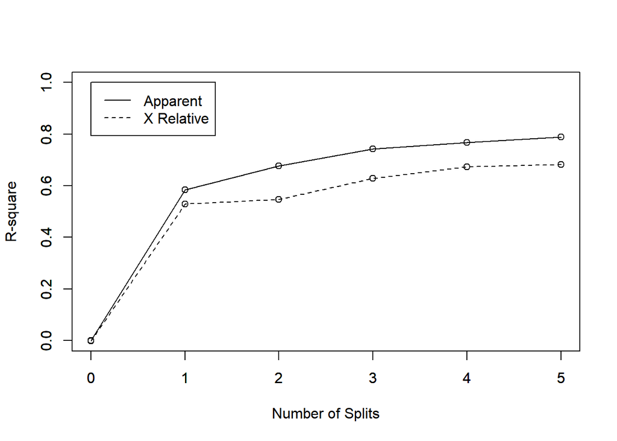

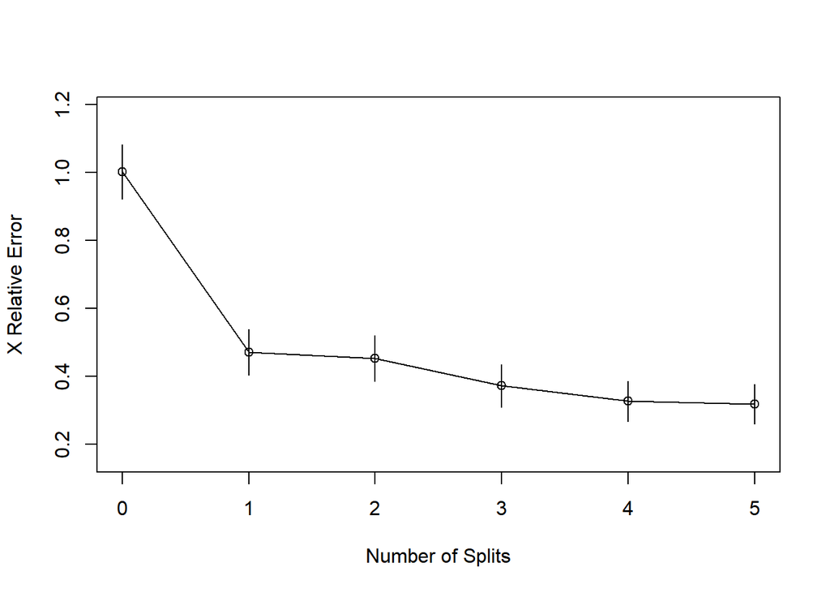

```r
accuracy(data1test$CAT.MEDV,tree.pred)
```

```
##                    ME      RMSE        MAE       MPE     MAPE
## Test set -0.005162735 0.1658026 0.05473207 -35.35229 213.7696
```

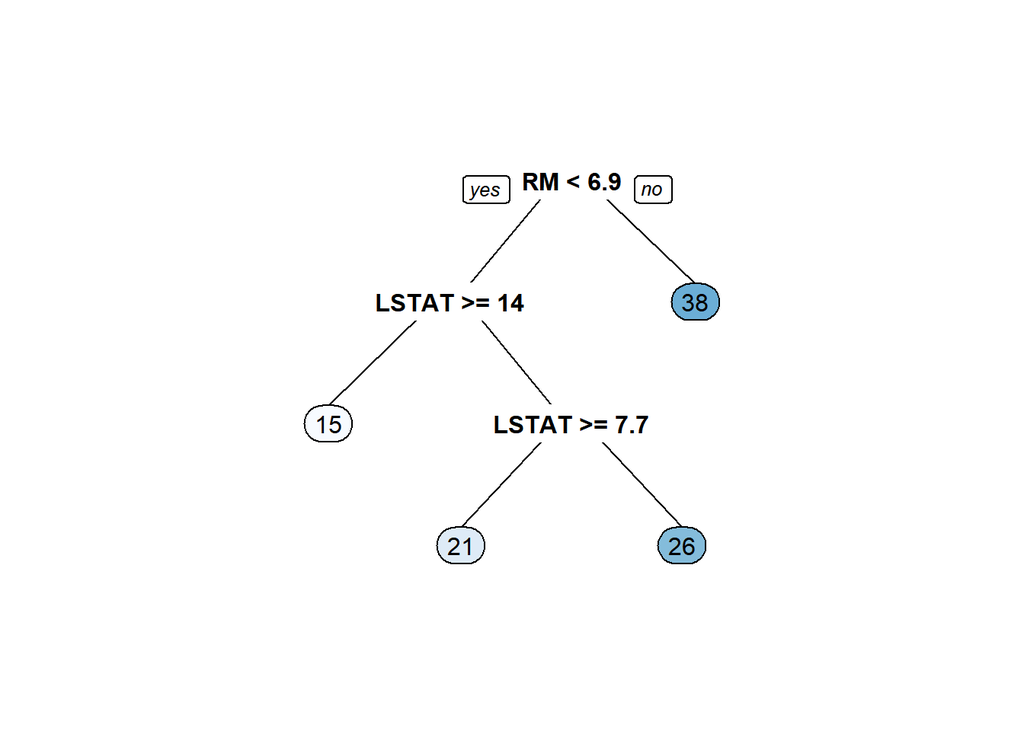

```r
tree2<-rpart(MEDV~ CRIM+ZN+INDUS+CHAS+NOX+RM+AGE+DIS+RAD+TAX+PTRATIO+B+LSTAT ,data=data1train,minbucket=50)
prp(tree2, box.palette="Blues")
```

```r
varImp(tree2)
```

```
##           Overall
## AGE     0.2934345
## CRIM    0.2752764
## INDUS   0.3235607
## LSTAT   1.1779063
## NOX     0.5420362
## PTRATIO 0.5738512
## RM      0.7458587
## ZN      0.0000000
## CHAS    0.0000000
## DIS     0.0000000
## RAD     0.0000000
## TAX     0.0000000
## B       0.0000000
```

```r
#rpart.plot(tree2,main="Regression Tree 2")
```

```r
tree2.pred = predict(tree2, newdata=data1test)
tree2.pred
```

```
##        1        2        3        4        5        6        7        8
## 26.22917 21.30089 21.30089 21.30089 21.30089 21.30089 14.78430 14.78430
##        9       10       11       12       13       14       15       16
## 14.78430 21.30089 14.78430 21.30089 21.30089 14.78430 26.22917 21.30089
##       17       18       19       20       21       22       23       24
## 26.22917 26.22917 21.30089 38.20968 21.30089 21.30089 21.30089 21.30089
##       25       26       27       28       29       30       31       32
## 38.20968 21.30089 14.78430 21.30089 14.78430 21.30089 21.30089 21.30089
##       33       34       35       36       37       38       39       40
## 21.30089 14.78430 14.78430 14.78430 14.78430 14.78430 14.78430 14.78430
##       41       42       43       44       45       46       47       48
## 14.78430 21.30089 14.78430 38.20968 21.30089 14.78430 21.30089 14.78430
##       49       50       51       52       53       54       55       56
## 26.22917 21.30089 21.30089 38.20968 26.22917 38.20968 26.22917 38.20968
##       57       58       59       60       61       62       63       64
## 14.78430 14.78430 14.78430 21.30089 21.30089 21.30089 14.78430 21.30089
##       65       66       67       68       69       70       71       72
## 14.78430 21.30089 21.30089 38.20968 21.30089 21.30089 21.30089 21.30089
##       73       74       75       76       77       78       79       80
## 26.22917 38.20968 21.30089 26.22917 21.30089 21.30089 38.20968 21.30089
##       81       82       83       84       85       86       87       88
## 38.20968 21.30089 14.78430 21.30089 21.30089 26.22917 21.30089 21.30089
##       89       90       91       92       93       94       95       96
## 21.30089 21.30089 21.30089 38.20968 26.22917 21.30089 21.30089 21.30089
##       97       98       99      100      101      102      103      104
## 38.20968 26.22917 26.22917 21.30089 14.78430 38.20968 14.78430 14.78430
##      105      106      107      108      109      110      111      112
## 14.78430 14.78430 14.78430 14.78430 14.78430 21.30089 21.30089 14.78430
##      113      114      115      116      117      118      119      120
## 14.78430 14.78430 14.78430 14.78430 14.78430 21.30089 14.78430 14.78430
##      121      122      123      124      125      126      127      128
## 14.78430 14.78430 14.78430 14.78430 14.78430 14.78430 14.78430 38.20968
##      129      130      131      132      133      134      135      136
## 14.78430 14.78430 14.78430 21.30089 14.78430 14.78430 14.78430 21.30089
##      137      138      139
## 14.78430 21.30089 38.20968
```

```r
#Stats
tree2.sse = sum((tree2.pred - data1test$MEDV)^2)
tree2.sse
```

```
## [1] 5636.962
```

```r
tree2.rmse= sqrt(mean((tree2.pred - data1test$MEDV)^2))
tree2.rmse
```

```
## [1] 6.368178
```

```r
RMSE0 = sd(data1test$MEDV-mean(data1test$MEDV))
r_sq = 1 - (tree2.rmse/RMSE0)
r_sq*100
```

```
## [1] 23.51036
```

```r
ssto=sum(tree2.pred -mean(data1test$MEDV)^2)
ssto
```

```
## [1] -60511.72
```

```r
r_sq1 = 1 - (tree2.sse/ssto)
r_sq1*100
```

```
## [1] 109.3155
```

```r
#rsq.rpart(tree2)
accuracy(data1test$MEDV,tree2.pred)
```

```
##                  ME     RMSE      MAE       MPE    MAPE
## Test set -0.3084368 6.368178 4.246667 -2.971091 20.2255
```

**Notes:**

About rpart: The R function rpart is an implementation of the CART [Classification and Regression Tree] supervised machine learning algorithm used to generate a decision tree. The R implementation is called rpart for Recursive PARTitioning. Like C50, rpart uses a computational metric to determine the best rule that splits the data, at that node, into purer classes. In the rpart algorithm the computational metric is the Gini coefficient. At each node, rpart minimizes the Gini coefficient and thus splits the data into purer class subsets with the class leaf nodes at the bottom of the decision tree. The process is simple to compute and runs fairly well, but our example will highlight some computational issues. The output from the R implementation is a decision tree that can be used to assign [predict] a class to new unclassified data items.

The option minbucket provides the smallest number of observations that are allowed in a terminal node. If a split decision breaks up the data into a node with less than the minbucket, it won’t accept it.

The minsplit parameter is the smallest number of observations in the parent node that could be split further. The default is 20. If you have less than 20 records in a parent node, it is labeled as a terminal node.

Finally, the maxdepth parameter prevents the tree from growing past a certain depth / height.The default is 30